# Venice is drowning - UCM model

# Overview

Come seconda parte del progetto, dopo aver provveduto ad effettuare costruzione di modelli ARIMA per la predizione della serie storica riguardante le maree, provvediamo a realizzare un Unobsserved Component Model (UCM).

# Preparazione dei dati

Provvediamo a caricare i dati:

```r
data <- read.csv("../data/output/df_final2010-2018.csv", header = T)
lunar_motion <- read.csv("../moon_distance/moon_distances.csv", header = T)
data$l_motion <- 1/lunar_motion$dists.Km.^2
```

Dopo aver importato i dati provvediamo, per mezzo del pacchetto *oce*, ad estrarre le 8 armoniche già utilizzate per la parte relativa ai modelli ARIMA dalla nostra serie:

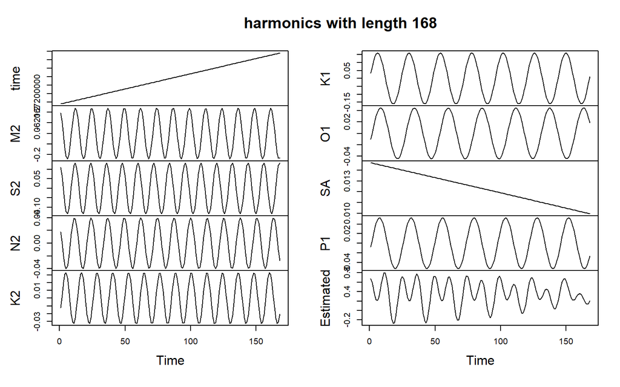

```r
datsl <- as.sealevel(data$level/100)
constituents <- c('M2', 'S2', 'N2', 'K2', 'K1', 'O1', 'SA', 'P1')
preds <- sapply(constituents, function(x){

  mod <- tidem(t = datsl, constituent = x)
  pred <- predict(mod)
  pred - mean(pred)

})
predall <- rowSums(preds) + mean(datsl[['elevation']])
preds <- data.frame(time = datsl[['time']], preds, Estimated = predall)

data$M2 <- preds$M2
data$S2 <- preds$S2
data$N2 <- preds$N2
data$K2 <- preds$K2
data$K1 <- preds$K1
data$O1 <- preds$O1
data$SA <- preds$SA
data$P1 <- preds$P1

plot.ts(preds[1:168,], main = "harmonics with length 168")
```

A questo punto limitiamo i dati al nostro intervallo di interesse:

```r
data <- data[74305:nrow(data),]
```

# Modello UCM

Dopo numerose prove, il modello che sembra performare al meglio è uno composto essenzialmente dalle armoniche inserite direttamente come componenti del modello, insieme ad una componente trend del tipo Random Walk. Sembrerebbe infatti che le armoniche risultino sufficienti a spiegare i moti stagionali all’interno della serie storica. Vale la pena di sottolineare che prima della realizzazione di questo report sono stati tentati approcci anche con ulteriori componenti stagionali, sia *dummy* che *trigonometriche*, e differenti manifestazioni della componente trend come *Local Linear Trend* e *Integrated Random Walk* ma tutti questi hanno dimostrato performance peggiori nella fase di previsione.

Partiamo definendo quindi la struttura del modello:

```r
mod1 <- SSModel(level/100 ~ 0 +
                  SSMtrend(1, NA)+
                  M2+
                  S2+
                  N2+
                  K2+
                  K1+
                  O1+
                  SA+
                  P1,
                H = NA,
                data = data[1:(nrow(data)-336),])
```

e controlliamo la struttura della matrici che lo compongono:

```r
mod1$Q
```

```
, , 1

     [,1]
[1,]   NA
```

```r
kable_styling(kable(mod1$T))
```

|  | M2.1 | S2.1 | N2.1 | K2.1 | K1.1 | O1.1 | SA.1 | P1.1 | level.1 |
| --- | --- | --- | --- | --- | --- | --- | --- | --- | --- |
| M2 | 1 | 0 | 0 | 0 | 0 | 0 | 0 | 0 | 0 |
| S2 | 0 | 1 | 0 | 0 | 0 | 0 | 0 | 0 | 0 |
| N2 | 0 | 0 | 1 | 0 | 0 | 0 | 0 | 0 | 0 |
| K2 | 0 | 0 | 0 | 1 | 0 | 0 | 0 | 0 | 0 |
| K1 | 0 | 0 | 0 | 0 | 1 | 0 | 0 | 0 | 0 |
| O1 | 0 | 0 | 0 | 0 | 0 | 1 | 0 | 0 | 0 |
| SA | 0 | 0 | 0 | 0 | 0 | 0 | 1 | 0 | 0 |
| P1 | 0 | 0 | 0 | 0 | 0 | 0 | 0 | 1 | 0 |
| level | 0 | 0 | 0 | 0 | 0 | 0 | 0 | 0 | 1 |

Procediamo quindi ad applicare una serie di correzioni; imponiamo ad esempio che le condizioni iniziali non siano diffuse, aggiungiamo il valore medio iniziale per il trend e la varianza iniziale per le componenti

```r
mod1$P1inf <- mod1$P1inf * 0
vary <- var(data$level[1:(nrow(data)-336)], na.rm = TRUE)
diag(mod1$P1) <- log(vary)
mod1$a1[9] <- mean(data$level[1:(nrow(data)-336)], na.rm = T)
```

Definiamo una update function custom, pur non essendocene bisogno poichè quella di default dovrebbe funzionare ugualmente avendo soltanto la varianza del Random Walk e quella dell’errore da ottimizzare ma avendo tentato molti approcci diversi con componenti che richiedevano la sua definizione abbiamo deciso di mantenerla

```r
pars <- numeric(5)
pars[1] <- log(vary/100)
pars[2] <- log(vary/100)
pars[3] <- log(vary/100)
pars[4] <- log(vary/100)
pars[5] <- log(0.01)

updt <- function(pars, model) {
  model$Q[1, 1, 1] <- exp(pars[1])
  model$H[1, 1, 1] <- exp(pars[4])
  model
}
```

Con la funzione di update abbiamo terminato la preparazione del modello: a questo punto non resta che avviare l’ottimizzazione

```r
fit1 <- fitSSM(mod1, pars, updt, control = list(maxit = 1000))
fit1$optim.out$convergence
```

```
[1] 0
```

L’output ci comunica che l’ottimizzatore è arrivato a convergenza. Proviamo a questo punto a rappresentare la previsione su **tutto** il nostro test set per verificare l’andamento della previsione.

# Risultati

Per fare ciò dobbiamo definire un nuovo modello con la variabile esplicativa compilata unicamente con NA values e con i parametri ottimizzati dal modello precedentemente ottimizzato

```r
lev <- c(rep(NA, 336))
temp_mod <- SSModel(lev ~ 0 +
                      SSMtrend(1, fit1$model$Q[1,1,1])+
                      M2+
                      S2+
                      N2+
                      K2+
                      K1+
                      O1+
                      SA+
                      P1,
                    H = fit1$model$H,
                    data = data[(4248+1):(4248+336),])


y_true <- data$level[4249:(4249+335)]
y_pred <- as.numeric(predict(fit1$model, newdata = temp_mod, n.ahead = 336))*100
```

Plottiamo i risultati su train e test per verificare la qualità della previsione

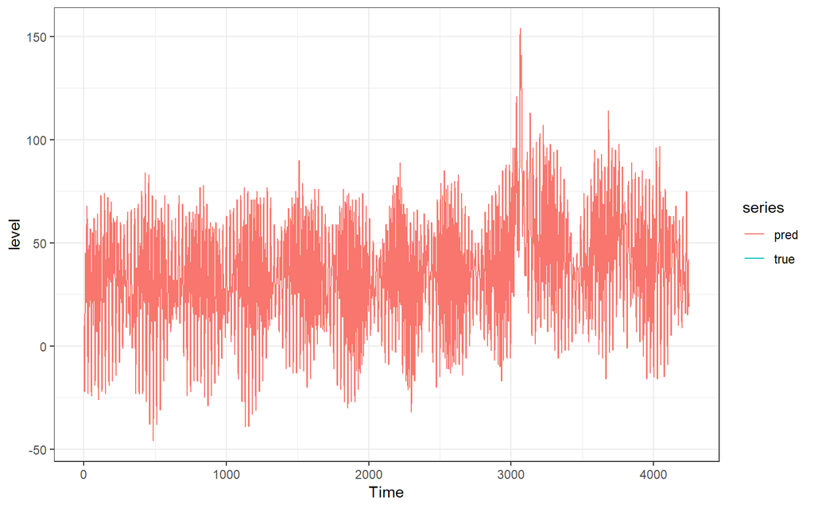

```r
smo1 <- KFS(fit1$model, smoothing = c("signal"))
autoplot(ts(data$level[1:4248]), series = "true") + theme_bw()+ autolayer(ts(smo1$muhat[1:4248]*100), series = "pred") + labs(y = "level")
```

Vediamo adesso i risultati in test

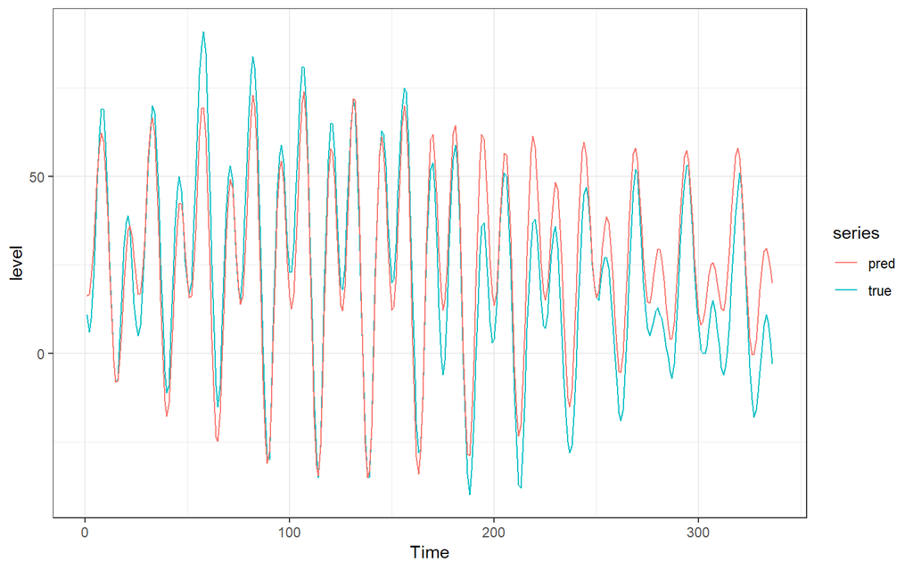

```r
autoplot(ts(y_true), series = "true") + theme_bw() + autolayer(ts(y_pred), series = "pred") + labs(y = "level")
```

I risultati in test sembrerebbero piuttosto buoni considerando anche il fatto che le due settimane prese in esame rappresentano i pattern particolare. Come è possibile notare infatti mentre nel periodo iniziale alle 06:00:00 del mattino è presente il picco di marea più alto della giornata seguito da quello delle 18-19:00:00 circa ad un certo punto i picchi arrivano ad una situazione in cui si equivalgono per poi invertirsi.

Procediamo a questo punto ad effettuare le valutazioni del modello: allo scopo di effettuare una valutazione più robusta abbiamo deciso di effettuare uno scoring di due tipi, un primo basato sulla previsione one-shot, ovvero prevedere come già fatto tutto l’orizzonte del test set e verificare come è andata la previsione 1 ora in avanti, 24 ore in avanti (come somma delle previsioni da 1 a 24 ore in avanti) e 168 ore in avanti (come somma degli errori di previsione da 1 a 168 ore in avanti), il secondo metodo invece consiste nell’iterare di un passo per 168 volte ed effettuare i 3 tipi di previsione in modo da verificare le effettive performances medie indipendentemente dal punto di partenza della previsione.

```r
step1 <- round(c(MAPE(y_pred[1], y_true[1]+0.1), RMSE(y_pred[1], y_true[1]+0.1)), 2)
steps24 <-  round(c(MAPE(y_pred[1:23], y_true[1:23]+0.1), RMSE(y_pred[1:23], y_true[1:23]+0.1)), 2)
steps168 <- round(c(MAPE(y_pred[1:length(y_pred)], y_true[1:length(y_true)]+0.1), RMSE(y_pred[1:length(y_pred)], y_true[1:length(y_true)]+0.1)), 2)

kable_styling(kable(matrix(c(step1, steps24, steps168), ncol = 3, nrow = 2, byrow = F, dimnames = list(c("MAPE", "RMSE"), c("1-step", "24-steps", "168-steps"))), caption = "One-shot performances"))
```

One-shot performances

|  | 1-step | 24-steps | 168-steps |
| --- | --- | --- | --- |
| MAPE | 0.47 | 0.34 | 2.51 |
| RMSE | 5.21 | 6.72 | 11.47 |

Le previsioni one-shot rispecchiano quanto visto nel plot della previsione. Provvediamo a questo punto ad effettuare le previsioni in rolling come anticipato:

```r
# 1 step ahead
score <- numeric(168)
for (i in 1:168){
  lev <- c(data$level[4248:(4247+i)]/100, rep(NA, 1))
  lev
  temp_mod <- SSModel(lev ~ 0 +
                        SSMtrend(1, fit1$model$Q[1,1,1])+
                        M2+
                        S2+
                        N2+
                        K2+
                        K1+
                        O1+
                        SA+
                        P1,
                      H = fit1$model$H,
                      data = data[(4247+1):(4247+i+1),])

  ucm_pred <- predict(fit1$model, newdata = temp_mod, n.ahead = 1)[(i+1):(i+1)]

  score[i] <- MAPE(ucm_pred, ((data$level[4248+i]/100)+0.001))
}

step1_ucm1 <- mean(score)

# 24 steps ahead
score <- numeric(168)
for (i in 1:168){
  lev <- c(as.numeric(data$level[4248:(4247+i)]/100), rep(NA, 24))
  temp_mod <- SSModel(lev ~ 0 +
                        SSMtrend(1, fit1$model$Q[1,1,1])+
                        M2+
                        S2+
                        N2+
                        K2+
                        K1+
                        O1+
                        SA+
                        P1,
                      H = fit1$model$H,
                      data = data[(4247+1):(4247+i+24),])

  ucm_pred <- predict(fit1$model, newdata = temp_mod, n.ahead = 24)[(i+1):(i+24)]

  score[i] <- MAPE(ucm_pred, (data$level[(4248+i):(4248+i+23)]/100)+0.001)
}

step24_ucm1 <- mean(score)

# 168 steps ahead
score <- numeric(168)
for (i in 1:168){
  lev <- c(as.numeric(data$level[4248:(4247+i)]/100), rep(NA, 168))
  temp_mod <- SSModel(lev ~ 0 +
                        SSMtrend(1, fit1$model$Q[1,1,1])+
                        M2+
                        S2+
                        N2+
                        K2+
                        K1+
                        O1+
                        SA+
                        P1,
                      H = fit1$model$H,
                      data = data[(4247+1):(4247+i+168),])

  ucm_pred <- predict(fit1$model, newdata = temp_mod, n.ahead = 168)[(i+1):(i+168)]

  score[i] <- MAPE(ucm_pred, (data$level[(4248+i):(4248+i+167)]/100)+0.001)
}

step168_ucm1 <- mean(score)
```

```r
kable_styling(kable(matrix(c(step1_ucm1, step24_ucm1, step168_ucm1), ncol = 3, nrow = 1, byrow = F, dimnames = list(c("MAPE"), c("1-step", "24-steps", "168-steps"))), caption = "Rolling performances"))
```

Rolling performances

|  | 1-step | 24-steps | 168-steps |
| --- | --- | --- | --- |
| MAPE | 0.1266869 | 0.5913087 | 2.14346 |

Le previsioni in rolling mostrano una coerenza di risultato ed un comprensibile aumento dell’errore a seconda dell’ampiezza della previsione a partire da 1 ora fino a 168 ore (una settimana) in avanti

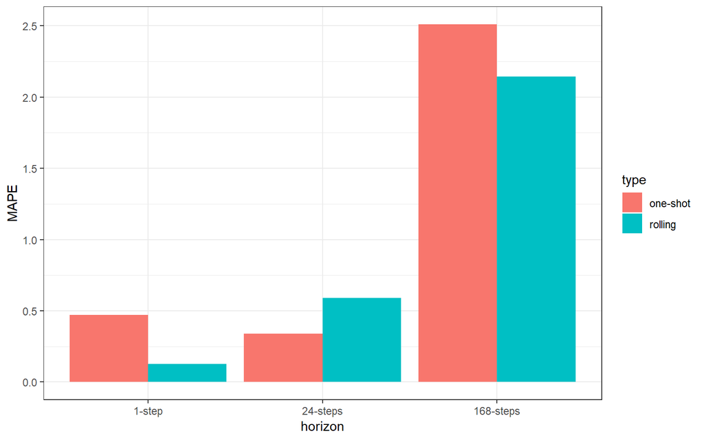

```r
perf <- data.frame(MAPE = c(step1[1], step1_ucm1, steps24[1], step24_ucm1, steps168[1], step168_ucm1),
           type = c("one-shot","rolling", "one-shot","rolling", "one-shot", "rolling"),
           horizon = c("1-step", "1-step", "24-steps", "24-steps", "168-steps", "168-steps"))

perf$horizon <- ordered(perf$horizon, levels = c("1-step", "24-steps", "168-steps"))
ggplot(data = perf, aes(fill = type, y = MAPE, x = horizon))+geom_bar(position = "dodge", stat = "identity")+theme_bw()
```

Dario Bertazioli, Fabrizio D’Intinosante

2020-01-26